# Praca domowa 2

Paweł Buczyński

## Dane

Dane wykorzystane w Pracy domowej 2 dotyczą wyników egzaminów z 3 umiejętności: czytania, pisania i operacji matematycznych. Dodatkowo dostępne są podstawowe informacje o studentach i ich rodzicach. Opis wszystkich kolumn znajduje się również w pliku `README.md`.

| Zmienna | Opis |
| --- | --- |
| **gender** | płeć |
| **race.ethnicity** | pochodzenie etniczne |
| **parental.level.of.education** | wykształcenie rodziców |
| **lunch** | jaki obiad jedli uczniowie w dniu egzaminu |
| **test.preparation.course** | czy uczeń odbył kurs przygotowujący |
| **math.score** | wynik egzaminu z matematyki |
| **reading.score** | wynik egzaminu z czytania |
| **writing.score** | wynik egzaminu z pisania |

## Zadanie 1

Jak wyglądają rozkłady wyników uczniów z trzech przedmiotów (matematyka, czytanie, pisanie)?

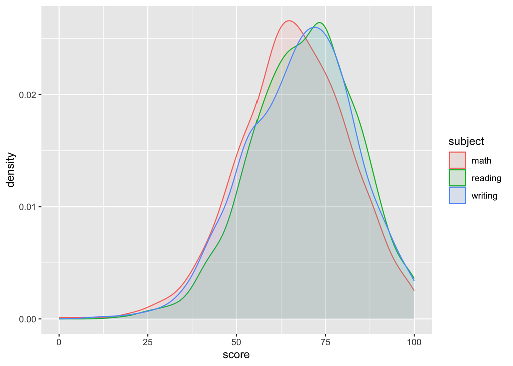

```r
library(tidyr)

df %>%
  tibble() %>%
  select(math.score, reading.score, writing.score) %>%
  pivot_longer(c(math.score, reading.score, writing.score),
               names_to = "subject", values_to = "score",
               names_pattern = "(\\w+)\\.score") %>%
  ggplot(aes(x = score, fill = subject, color = subject)) +
  geom_density(alpha = 0.1)
```

**Komentarz:** Rozkład jest zbliżony do normalnego i podobny ze wszystkich przedmiotów. Z matematyki jest przesunięty delikatnie w lewo, co oznacza niższe wyniki.

## Zadanie 2

Czy istnieje zauważalna różnica w wynikach między uczniami i uczennicami?

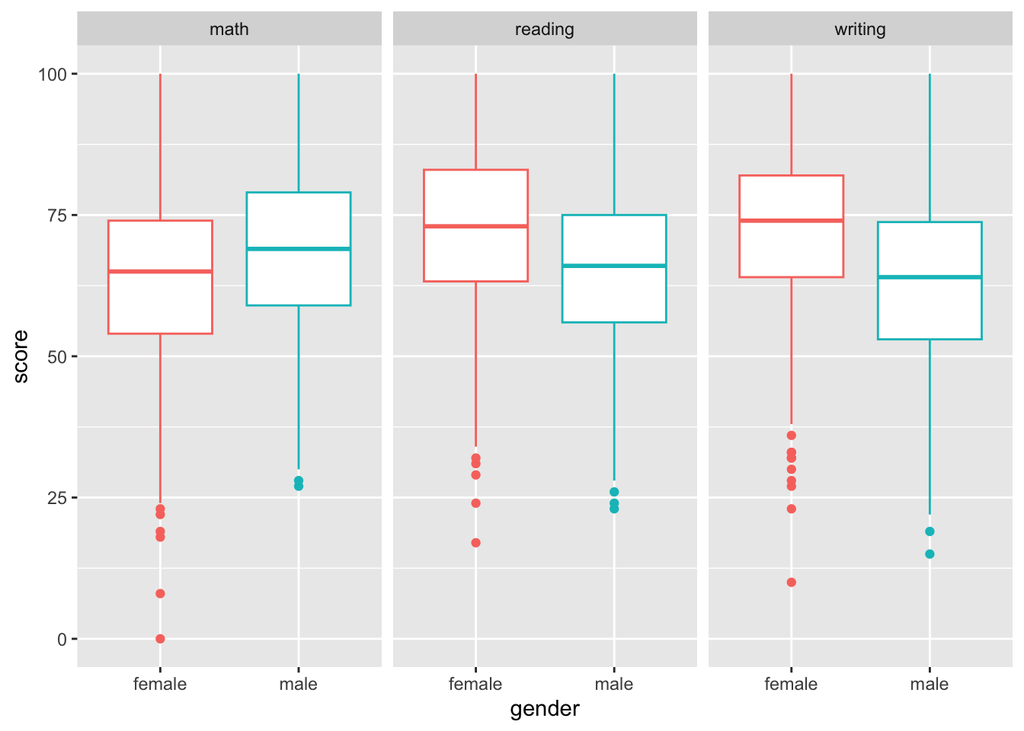

```r
df %>%
  tibble() %>%
  pivot_longer(cols = ends_with(".score"), names_to = "subject", values_to = "score", names_pattern = "(\\w+)\\.score") %>%
  select(gender, subject, score) %>%
  ggplot(aes(y = score, color = gender, x = gender)) +
  facet_wrap(vars(subject)) +
  geom_boxplot() +
  theme(legend.position = "none")
```

**Komentarz:** Tak - uczniowie osiągają wyższe wyniki w matematyce, a uczennice w czytaniu i pisaniu, przy czym przewaga uczennic w czytaniu i pisaniu (~1 kwartyl) jest większa niż uczniów w matematyce (~0,5 kwartyla).

## Zadanie 3

Czy uczniowie, którzy ukończyli kurs przygotowawczy, osiągają lepsze wyniki niż pozostali?

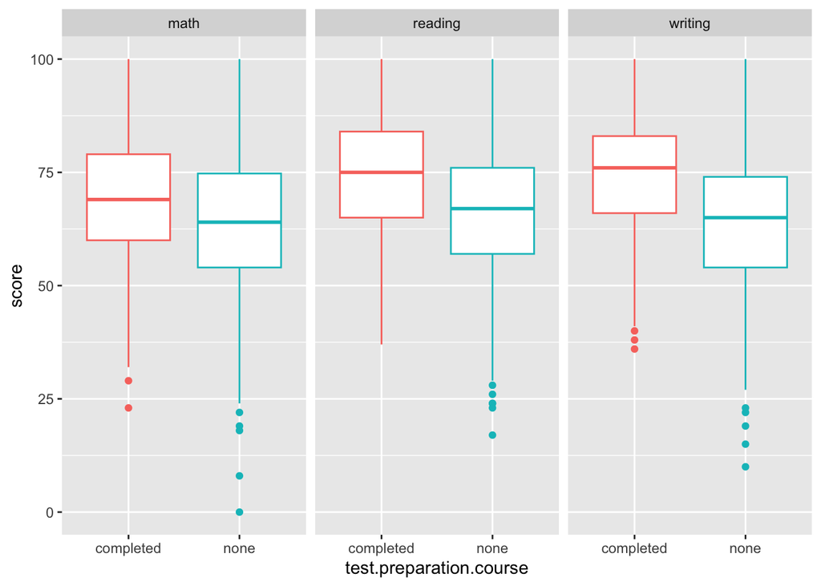

```r
df %>%
  tibble() %>%
  pivot_longer(cols = ends_with(".score"), names_to = "subject", values_to = "score", names_pattern = "(\\w+)\\.score") %>%
  select(test.preparation.course, subject, score) %>%
  ggplot(aes(y = score, x = test.preparation.course, color = test.preparation.course)) +
  facet_wrap(vars(subject)) +
  geom_boxplot() +
  theme(legend.position = "none")
```

**Komentarz:** Tak, przy czym w matematyce różnica jest mniejsza (~0,5 kwartyla) niż w czytaniu i pisaniu (~1 kwartyl).

## Zadanie 4

Jaki jest związek między poziomem wykształcenia rodziców a średnimi wynikami uczniów?

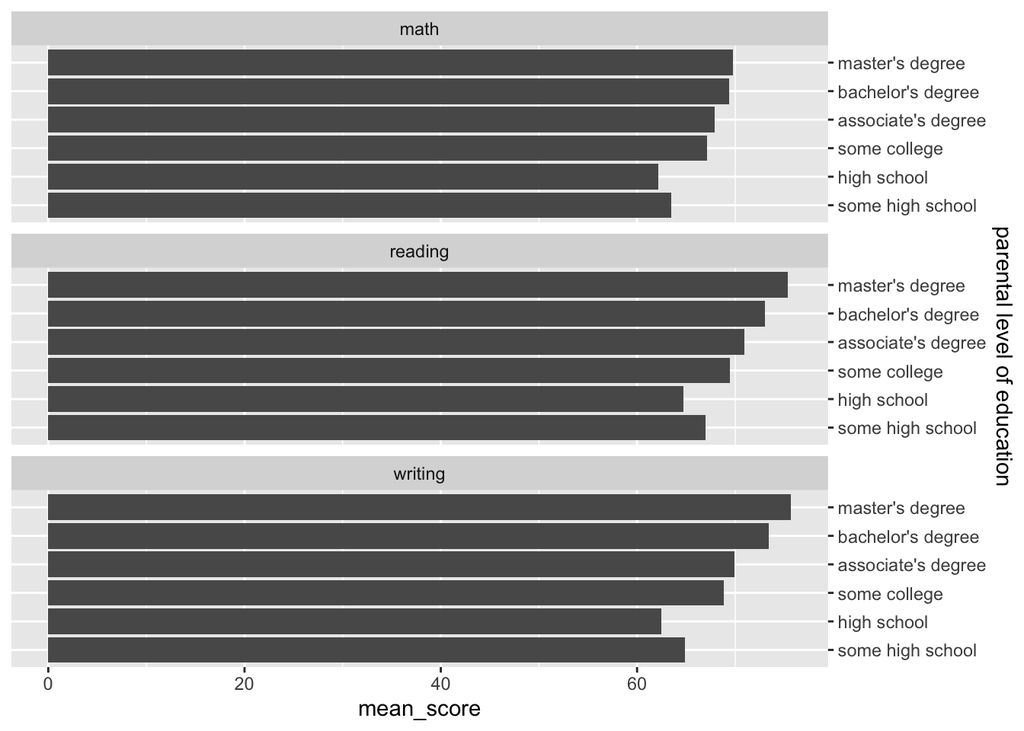

```r
library(forcats)

levels <- c("some high school", "high school", "some college", "associate's degree", "bachelor's degree", "master's degree")

df %>% tibble() %>%
  pivot_longer(cols = ends_with(".score"), names_to = "subject", values_to = "score", names_pattern = "(\\w+)\\.score") %>%
  group_by(parental.level.of.education, subject) %>%
  summarise(mean_score = mean(score)) %>%
  ggplot(aes(y = fct_reorder(parental.level.of.education, match(parental.level.of.education, levels)), x = mean_score)) +
  geom_col() +
  facet_wrap(vars(subject), ncol = 1) +
  labs(y = "parental level of education") +
  scale_y_discrete(position = "right")
```

**Komentarz:** Im wyższy poziom wykształcenia rodziców, tym wyższe średnie wyniki uczniów. Różnice są małe, ale korelacja jest wyraźnie widoczna. Wyjątkiem jest wyższy wynik “some high school” niż “high school”, być może część rodziców jej nie ukończyła bo znaleźli pracę albo założyli własną działalność (a nie dlatego że nie dali rady), zapewniając potem dzieciom lepsze warunki do nauki.

## Zadanie 5

Czy płeć i wykształcenie rodzica wpływa na wynik z matematyki?

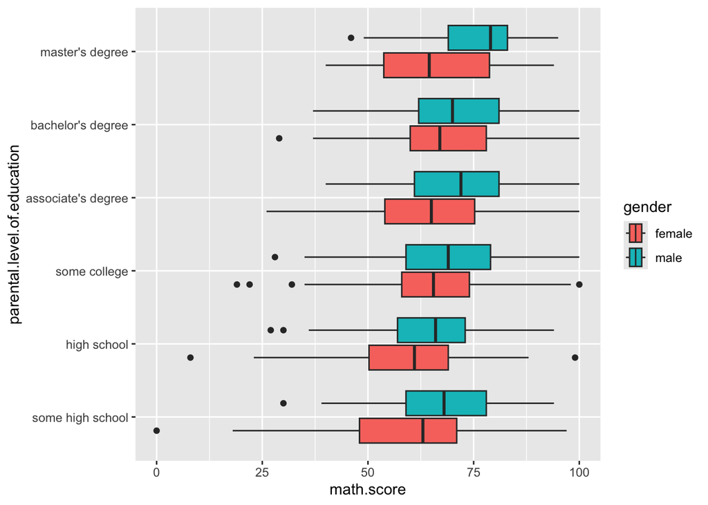

```r
levels <- c("some high school", "high school", "some college", "associate's degree", "bachelor's degree", "master's degree")

df %>% tibble() %>%
  select(parental.level.of.education, gender, math.score) %>%
  mutate(parental.level.of.education = fct_reorder(parental.level.of.education, match(parental.level.of.education, levels))) %>%
  group_by(gender, parental.level.of.education) %>%
  ggplot(aes(x = math.score, y = parental.level.of.education, fill = gender)) +
  geom_boxplot()
```

```r
  #scale_y_discrete(position = "right") +
  #theme(legend.position = "left")
```

## Zadanie 6

Czy istnieje zależność między wynikami z matematyki a wynikami z czytania lub pisania?

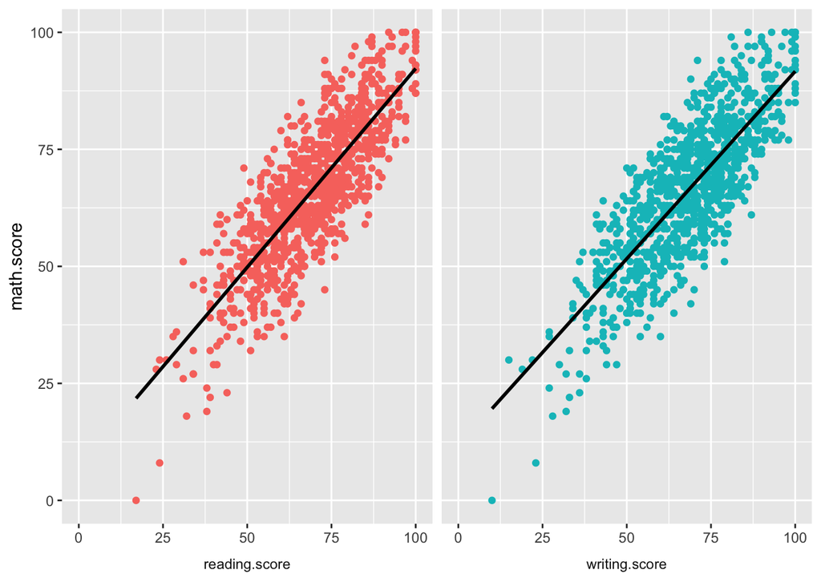

```r
df %>% tibble() %>%
  select(math.score, reading.score, writing.score) %>%
  pivot_longer(cols = c(reading.score, writing.score),
               values_to = "score") %>%
  ggplot(aes(x = score, y = math.score, color = name)) +
  geom_point() +
  geom_smooth(method = "lm", se = FALSE, color = "black") +
  xlim(0, 100) +
  ylim(0, 100) +
  facet_wrap(vars(name), strip.position = "bottom") +
  theme(legend.position = "none",
        axis.title.x = element_blank(),
        strip.background = element_blank(),
        strip.placement = "outside")
```

**Komentarz:** Tak, w obu przypadkach widać taką samą wyraźną korelację liniową - im wyższy wynik z matematyki, tym wyższy z czytania/pisania.